# 关于摩拜单车的探索性分析

## 数据简介

随着共享经济的发展，共享单车应运而生，“行”作为四大民生需求（衣食住行）的一部分，探索其在新形态经济下的发展态势以及存在的问题尤为重要。本次数据选用摩拜单车的数据，共包含102361条摩拜单车订单记录，包含的变量有：orderid（订单编号）、bikeid（车辆编号）、userid（用户编号）、start_time（开始骑行时间）、start_location_x（起点维度位置）、start_location_y（起点经度位置）、end_time（到达终点时间）、end_location_x（终点维度位置）、end_location_y（终点经度位置）、track（轨迹点），希望通过各个特征的不同维度的分析，了解共享单车目前的发展态势以及存在的问题。

## 数据结构与概况

该数据集的大部分变量的数据类型为数值型，如地理位置（起止点），骑行轨迹，骑行时长，骑行起止时间，其次订单编号、用户编号以及车辆编号为字符型；  
该数据集因为骑行时长中存在少量的异常值，清理后的数据集在源数据集的基础上移除部分，约占源数据量的0.02%，对分析结果基本无影响。

## 数据探索概述

本次单车的数据探索中，主要想集中于对于单车在上海各个城区内使用量的地理位置分布、用户偏好以及用户价值这三方面进行探索，需要探索的主要度量为订单数量、骑行时长、地理位置。

## 探索骑行时长的数据分布

骑行时长存在较大的数据分布差异，数据分布右向偏度较大，所以对骑行时长进行对数变换，从而增加区间内数据分布的粒度。从下图可以得出，大部分用户的骑行时长维持在5-10分钟之间，超过7分钟后，骑行人数随着时长的增加而快速减少。

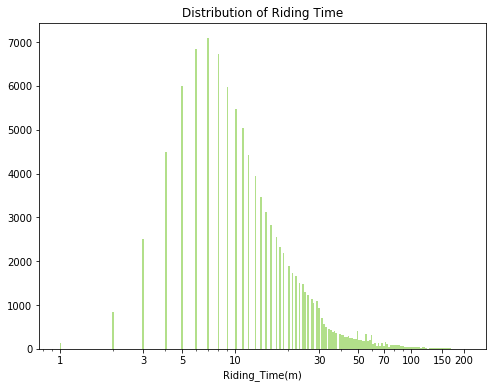

```python
# 数据严重右偏，对riding_time轴进行对数变换
plt.figure(figsize=(8,6))
bin_edge = 10**np.arange(0,np.log10(mobike_df2.riding_time.max())+0.01,0.01)
plt.hist(data=mobike_df2,x='riding_time',bins=bin_edge,color=colorful[2])
plt.xscale('log')
plt.xticks(ticks=[1,3,5,10,30,50,70,100,150,200],labels=[1,3,5,10,30,50,70,100,150,200])
plt.xlabel('Riding_Time(m)')
plt.title('Distribution of Riding Time');
```

## 探索日期时间上的数据分布

为了探索整个8月份连续性的骑行日期时间，将日期型数据转换成连续型的浮点型数值，数值越大，所属的日期时间越大。 从下图可以看出，随着日期时间的推移，订单数量呈波段式增长趋势，图中共有31个波段，每一个波段对应一天，而一天中也都基本呈现着双峰结构，推断对应着早晚高峰，而日期与日期之间则是夜间凌晨，夜间凌晨的数据量处于低峰。

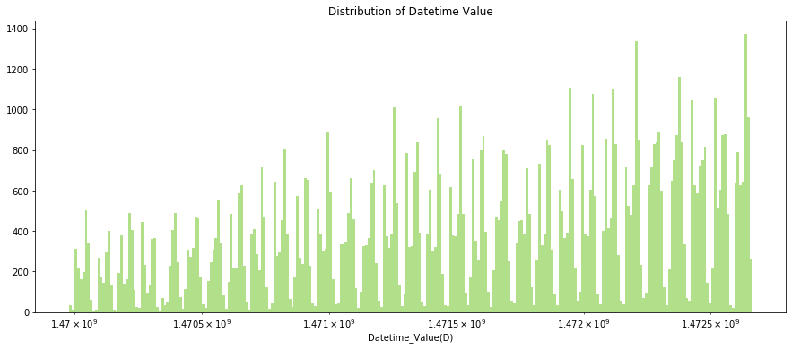

```python
# 探索时间上的订单总量的数据分布
fig,axes = plt.subplots(figsize=(15,6))
colorful = sns.color_palette('Paired')
sns.distplot(datetime_value,bins=bin_edge,hist_kws={'color':colorful[2],'alpha':1},kde=False,ax=axes)
axes.set_xscale('log')
axes.set_xlabel('Datetime_Value(D)')
axes.set_title('Distribution of Datetime Value');
```

## 探索地理位置的数据分布

起点和终点的聚集区域基本一致，经度集中在（121.4-121.5）之间，维度集中在（31.2-31.3）之间，存在少量偏远的起点和终点。

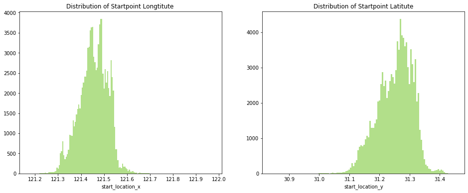

```python
# 探索起点经度和维度的数据分布
fig,axes = plt.subplots(1,2,figsize=(16,6))
bin_edge1 = np.arange(mobike_df2.start_location_x.min(),mobike_df2.start_location_x.max()+0.005,0.005)
sns.distplot(mobike_df2.start_location_x,bins=bin_edge1,kde=False,hist_kws={'alpha':1,'color':colorful[2]},ax=axes[0])
axes[0].set_title('Distribution of Startpoint Longtitute ')
bin_edge2 = np.arange(mobike_df2.start_location_y.min(),mobike_df2.start_location_y.max()+0.005,0.005)
sns.distplot(mobike_df2.start_location_y,bins=bin_edge2,kde=False,hist_kws={'alpha':1,'color':colorful[2]},ax=axes[1])
axes[1].set_title('Distribution of Startpoint Latitute');
```

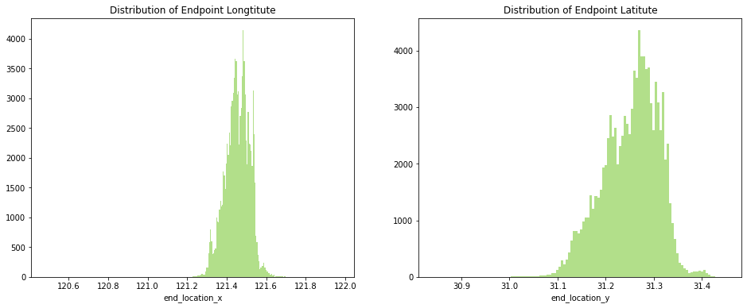

```python
# 探索起点经度和维度的数据分布
fig,axes = plt.subplots(1,2,figsize=(16,6))
bin_edge3 = np.arange(mobike_df2.end_location_x.min(),mobike_df2.end_location_x.max()+0.005,0.005)
sns.distplot(mobike_df2.end_location_x,bins=bin_edge3,kde=False,hist_kws={'alpha':1,'color':colorful[2]},ax=axes[0])
bin_edge4 = np.arange(mobike_df2.end_location_y.min(),mobike_df2.end_location_y.max()+0.005,0.005)
sns.distplot(mobike_df2.end_location_y,bins=bin_edge2,kde=False,hist_kws={'alpha':1,'color':colorful[2]},ax=axes[1]);
axes[0].set_title('Distribution of Endpoint Longtitute')
axes[1].set_title('Distribution of Endpoint Latitute');
```

## 订单总量和骑行总时长在日期上的分布

随着日期的推移，订单总量和骑行总时长呈快速增长趋势

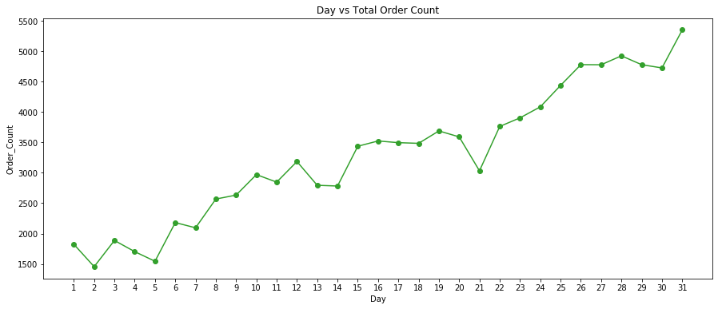

```python
# 探索订单总量随着日期的推移的变化趋势
plt.figure(figsize=(15,6))
day_count = mobike_df2.start_time.dt.day.value_counts().sort_index()
plt.plot(day_count.index,day_count.values,marker='o',color=colorful[3])
plt.xticks(ticks=range(1,32,1),labels=range(1,32,1))
plt.xlabel('Day',fontsize=10)
plt.ylabel('Order_Count',fontsize=10)
plt.title('Day vs Total Order Count');
```

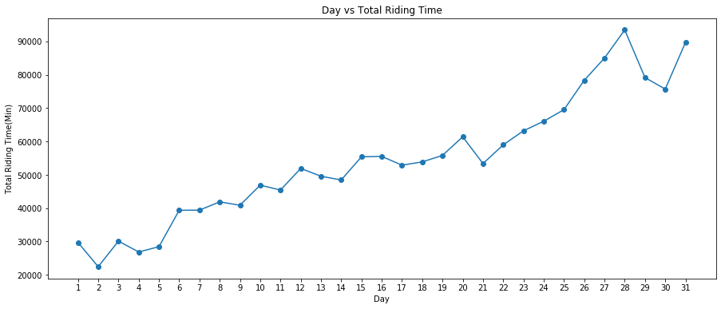

```python
# 探索骑行总时长在日期上的分布
plt.figure(figsize=(15,6))
riding_time_total = mobike_df2.groupby('day')['riding_time'].sum()
plt.plot(riding_time_total.index,riding_time_total,marker='o');
plt.xticks(ticks=range(1,32,1),labels=range(1,32,1))
plt.xlabel('Day',fontsize=10)
plt.ylabel('total riding time(min)'.title(),fontsize=10)
plt.title('Day vs Total Riding Time');
```

## 订单总量和骑行时长在时间上的分布

- 在一天内的时间变化中，订单总量呈现明显的早晚高峰时段：7-9点骑行量较大，8点左右达到上午高峰值，17-20点骑行量较大，18点左右达到高峰，晚高峰的订单数量大于早高峰的订单数量，而夜间和凌晨(0-5)期间，订单数量达到低峰，所以运营商应该在发生骑行次数较少的时段，如凌晨23-5点或者9-15点进行车辆的投放或维修，以备高峰时段有足够的质量良好的车辆供用户使用。
- 骑行的总时长因为订单总量的影响，数据呈现与订单总量在时间维度的分布上基本一致，但从骑行的平均时长上来看，晚上（18点以后）用户的骑行时长大于白天，大致可以推断用户在晚上（如下班后）骑车有更充裕的时间或者愿意花费更多的时间，而上午的时间相对比较紧张；

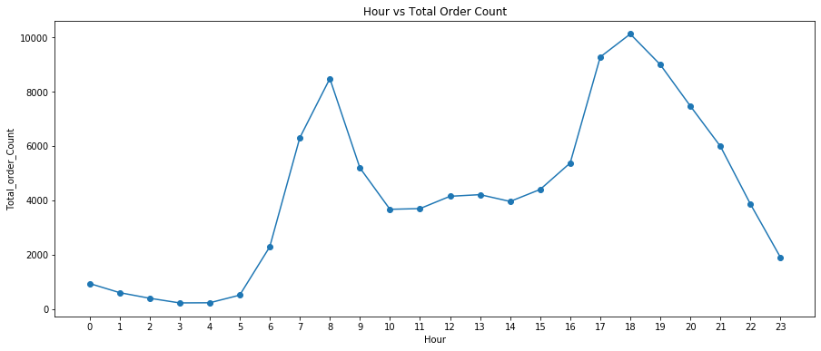

```python
# 探索订单总量在一天内的不同时间段是否存在较大的数据差异，即是否存在高低峰期
plt.figure(figsize=(15,6))
hour_count = mobike_df2.start_time.dt.hour.value_counts().sort_index()
plt.plot(hour_count.index,hour_count.values,marker='o')
plt.xticks(ticks=range(0,24,1),labels=range(0,24,1))
plt.xlabel('Hour',fontsize=10)
plt.ylabel('Total_order_Count',fontsize=10)
plt.title('Hour vs Total Order Count');
```

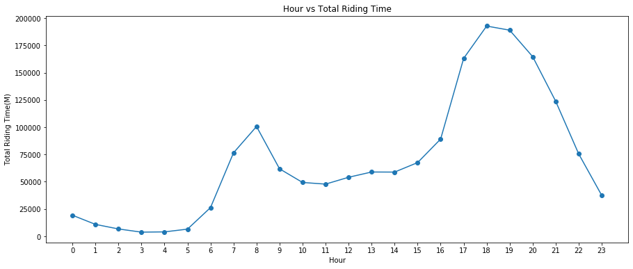

```python
# 探索骑行总时长在一天内的每个时间段内的数据
plt.figure(figsize=(15,6))
hour_riding_time = mobike_df2.groupby('hour')['riding_time'].agg('sum')
plt.plot(hour_riding_time.index,hour_riding_time.values,marker='o')
plt.xticks(ticks=range(0,24,1),labels=range(0,24,1))
plt.xlabel('Hour',fontsize=10)
plt.ylabel('total riding time(m)'.title(),fontsize=10)
plt.title('Hour vs Total Riding Time');
```

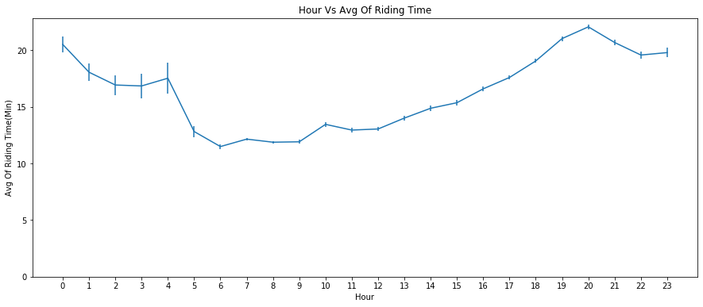

```python
# 同样骑行总时长会受到订单量的影响，进而探索骑行的平均时长在各个时间段内的数据
plt.figure(figsize=(15,6))
riding_time_avg2 = mobike_df2.groupby('hour')['riding_time'].mean()
riding_time_sem2 = mobike_df2.groupby('hour')['riding_time'].sem()
plt.errorbar(x=riding_time_avg2.index,y=riding_time_avg2,yerr=riding_time_sem2);
plt.xticks(ticks=range(0,24,1),labels=range(0,24,1))
plt.ylim(bottom=0)
plt.xlabel('Hour',fontsize=10)
plt.ylabel('avg of riding time(min)'.title(),fontsize=10)
plt.title('Hour vs avg of riding time'.title());
```

## 骑行平均时长在工作日和非工作日上的分布

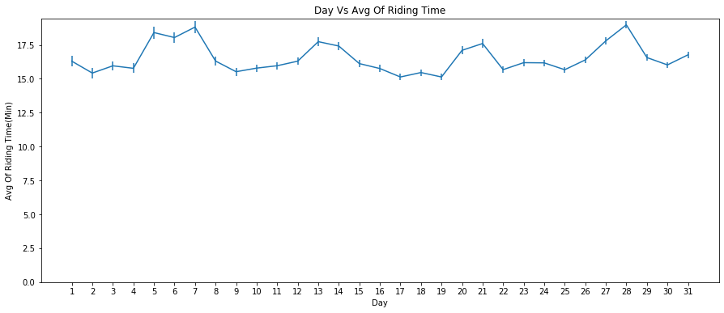

```python
# 因为骑行总时长受订单量的影响，为了进一步探索，需要分析骑行平均时长在8月每一天的分布
plt.figure(figsize=(15,6))
riding_time_avg = mobike_df2.groupby('day')['riding_time'].mean()
riding_time_sem = mobike_df2.groupby('day')['riding_time'].sem()
plt.errorbar(x=riding_time_avg.index,y=riding_time_avg,yerr=riding_time_sem);
plt.xticks(ticks=range(1,32,1),labels=range(1,32,1))
plt.ylim(bottom=0)
plt.xlabel('Day',fontsize=10)
plt.ylabel('avg of riding time(min)'.title(),fontsize=10)
plt.title('Day vs avg of riding time'.title());
```

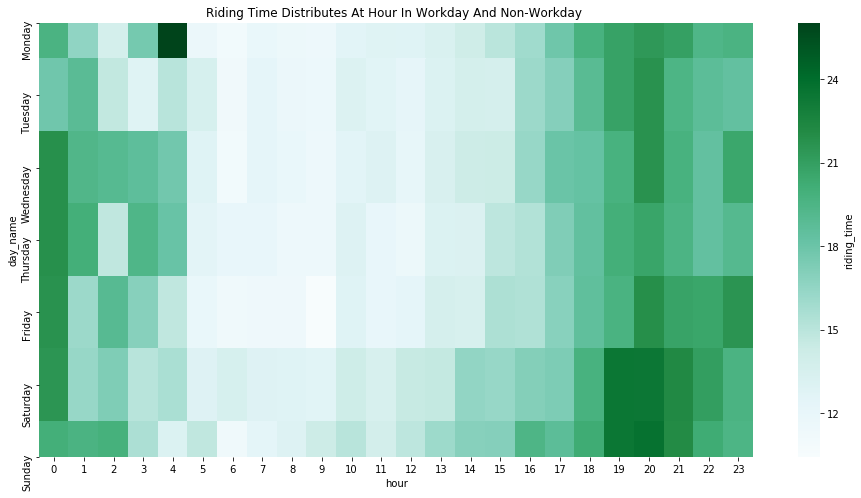

```python
plt.figure(figsize=(16,8))
sns.heatmap(data=day_hour_time_pivot,cmap='BuGn',cbar_kws={'label':'riding_time'})
plt.title('riding time distributes at hour in workday and non-workday '.title());
```

## 车辆使用量在地理位置上分布

- 从行政区划上来看，车辆使用主要集中在虹口区、黄浦区、静安区，而距离上海中心城区较远的普陀区、长宁区、徐汇区和浦东新区车辆使用量相对较低；
- 从城市特征上来看，车辆使用主要集中在大学城区、体育馆、大型商圈、密集住宅区及主要交通干道交汇处（立交桥，交通枢纽）等地段；
  - 以同济和复旦大学为代表的大学城区，江湾体育场，内环共和立交桥，中环虹桥枢纽等
  - 黄浦区各个以中国城市命名的主要街道，人民广场
- 从地铁沿线上来看：1号线，3号线，11号线和13号线是车辆高频使用沿线；

```python
HTML('<iframe src=st_loc_heatmap.html width=700 height=450></iframe>')
```

[interactive chart not shown]

通过调用百度地图API，得出地理信息更为详细的热力图，详情请查看`Mobike Data/Mobike_location_heatmap.html`

## 车辆运行轨迹的轨迹位置分布

- 骑行主要是以短距离为主，长距离比较少
- 骑行的主要活动区域正如上述热力图所示，主要集中在中心城区，如虹口区、黄埔区、杨浦区
- 黄浦沿江区域的骑行轨迹较多

以下是使用Tableau绘制的关于单车骑行的轨迹图

[Tableau Public-Mobike Trace Chart](https://public.tableau.com/profile/novel.an#!/vizhome/MobikeTraceChart/Sheet1?publish=yes)

## 对用户价值的探索

- 以userid为分组依据，假设当前日期是2016年9月1日，得出每个用户当前日期距离最近使用车辆的日期的天数差（recent_day_diff）、累计骑行时长（riding_time_total）、累计骑行次数（order_count）
- 因为该数据集仅为8月这一个月的单车订单数据，从recent_day_diff图可知，发生在最近的骑行占比较大，而且从上述订单量随着日期增长而不断增长的数据可知，随着摩拜单车的不断推广，新用户的数量在不断增长，且增速越来越大。
- 单个用户在8月的累计骑行时长集中在50-100分钟之间，单个用户在8月的累计骑行次数多集中在2-8次，少数用户有高达20次以上的使用

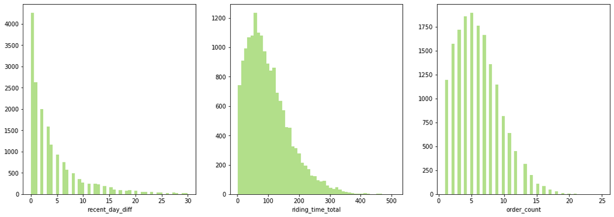

```python
fig,axes = plt.subplots(1,3,figsize=(18,6))
sns.distplot(R,kde=False,hist_kws = {'alpha' : 1},ax=axes[0],color=colorful[2])
axes[0].set_xlabel('recent_day_diff')
sns.distplot(M,kde=False,hist_kws = {'alpha' : 1},ax=axes[1],color=colorful[2])
axes[1].set_xlabel('riding_time_total')
sns.distplot(F.values,kde=False,hist_kws = {'alpha' : 1},ax=axes[2],color=colorful[2])
axes[2].set_xlabel('order_count');
```

根据上述三类特征数据的数据分布图，具体分箱出各个特征下的不同数值区间的对应分值（满分均为5分），如下所示：

| RFM | Data Bin | Grades |
| --- | --- | --- |
| Recency | 0-5 | 5 |
| Recency | 6-11 | 4 |
| Recency | 12-17 | 3 |
| Recency | 18-23 | 2 |
| Recency | 24-30 | 1 |
| Frequency | >=15 | 5 |
| Frequency | 12-14 | 4 |
| Frequency | 10-11 | 3 |
| Frequency | 6-9 | 2 |
| Frequency | 0-5 | 1 |
| Monetary(riding time total) | >=300 | 5 |
| Monetary(riding time total) | 200-299 | 4 |
| Monetary(riding time total) | 100-199 | 3 |
| Monetary(riding time total) | 50-99 | 2 |
| Monetary(riding time total) | 0-49 | 1 |

#### 将数据集的三项数据与三项平均值作对比，将客户价值按照下图所示划分

[figure not shown]

## 统计各类客户的占比

- 重要价值客户、新客户、流失客户和潜力客户的占比较大，其中重要价值客户的占比最大，高达31.7%，新用户的占比仅次于重要价值客户的占比，也占据28.1%的用户，这一分析结果也再次论证，摩拜单车目前正处于上升期或者说快速扩张期，为了快速占领市场流量和提高公司的知名度，公司目前大量投放单车，新用户快速增长；
- 流失客户也存在较大的占比，在占比数据上排第三，公司需要对于流失率上进行进一步的分析，如用户体验，产品质量，竞争者数量，或者公共关系等原因。
- 当然重要价值客户的占比最高，所以在继续保持优势的基础上，可以根据不同的客户价值群体，采取相应的运营措施：如推送折扣月卡，不定期发送免费骑车券，与其他公司合作，可以使用骑行里程兑换礼品等。

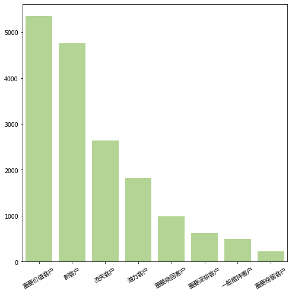

```python
# 统计各类客户的占比
value_counts = user_rfm.user_value.value_counts()
fig,ax = plt.subplots(figsize=(8,8))
sns.barplot(x=value_counts.index,y=value_counts.values,color=colorful[2])
plt.xticks(rotation=30);
```

##### 通过5W1H的分析方法与日期时间维度的结合，得出以下结论：

1. 车辆的重复使用率为21.36%，而用户的重复使用率是92.92%。衣食住行中的行属于刚性需求，用户复用率之高反映了用户的需求量大之外，还反映了用户对于产品的初步认可或者竞争者数量较少等原因，而车辆的复用率之低可能是由于目前市场投放的车辆数量远大于需求量，从而造成供过于求的局面，也有可能产品破损严重，所以需要根据相关数据再作分析。
2. 基于日期和时间维度的分析：
   - 随着日期的推移，订单总量和骑行总时长呈快速增长趋势；
   - 在一天内的时间变化中，订单总量呈现明显的早晚高峰时段：7-9点骑行量较大，8点左右达到上午高峰值，17-20点骑行量较大，18点达到一天的高峰值，所以运营商应该在非高峰时段，如凌晨23-5点或者10-15点进行车辆的投放或维修，以备高峰时段有足够的质量良好的车辆供用户使用；
   - 骑行的总时长因为订单总量的影响，数据呈现与订单总量在时间维度的分布上基本一致，但从骑行的平均时长上来看，晚上（18点以后）用户的骑行时长大于白天，大致可以推断用户有更充裕的时间或者愿意花费更多的时间在晚上（如下班后）骑车，而上午的时间相对比较紧张；
   - 从工作日和非工作日上来分析，周六周日的平均骑行时长大于工作日的平均骑行时长；
3. 基于地理位置的分析：
   - 从行政区划上来看，车辆使用主要集中在虹口区、黄浦区、静安区，而普陀区、长宁区、徐汇区和浦东新区车辆使用量相对较低；
   - 从城市特征上来看，车辆使用主要集中在大学城区、体育馆、大型商圈、密集住宅区及主要交通干道交汇处（立交桥，交通枢纽）等地段；
     - 以同济和复旦大学为代表的大学城区，江湾体育场，内环共和立交桥，中环虹桥枢纽等
     - 黄浦区各个以中国城市命名的主要街道，人民广场
   - 从地铁沿线上来看：1号线，3号线，11号线和13号线是车辆高频使用沿线；
   - 从骑行轨迹上开看：
     - 骑行主要是以短距离为主，长距离的轨迹点多的比较少；
     - 骑行的主要活动区域正如上述热力图所示，主要集中在中心城区，如虹口区、黄埔区、杨浦区；
     - 黄浦沿江区域的骑行轨迹较多；

##### 通过RFM模型对用户价值进行了探索分析，得出以下结论：

1. 基于用户的分析：
   - 随着摩拜单车在市场的不断推广，新用户的数量呈现快速增长趋势；
   - 大部分用户骑行时长在5-10分钟，单个用户在8月的累计骑行次数集中在3-7次，少数用户有高达20次以上的使用量；
   - 重要价值客户、新客户、流失客户和潜力客户的占比较大，其中重要价值客户的占比最大，高达31.7%，新用户的占比仅次于重要价值客户的占比，也占据28.1%的用户，这一分析结果也再次论证，摩拜单车目前正处于上升期或者说快速扩张期，为了快速占领市场流量和提高公司的知名度，公司目前大量投放单车，新用户快速增长；
   - 流失客户也存在较大的占比，在占比数据上排第三，公司需要对于流失率上进行进一步的分析，如用户体验，产品质量，竞争者数量，或者公共关系等原因。
   - 当然重要价值客户的占比最高，所以在继续保持优势的基础上，可以根据不同的客户价值群体，采取相应的运营措施：如推送折扣月卡，不定期发送免费骑车券，与其他公司合作，可以使用骑行里程兑换礼品等；